# Caso CRM

Ikonosoft S A S

# Situación

Hasta la fecha hemos construido 22 sistemas de gestión de clientes (CRM por sus siglas en inglés).

Nuestros clientes requerían sistemas confiables de CRM, que les facilitaran el análisis de información relevante para la toma de decisiones efectivas, en relación con los procesos de ventas, clientes y negocios facturados. Estos sistemas les permitirían fortalecer la relación con sus clientes, impulsando su rentabilidad y sostenibilidad, tomando en consideración que una sólida relación con los clientes se traduce en recompras y recomendaciones.

# Proceso de Construcción de un CRM

Nuestros sistemas de CRM se elaboran a la medida de cada organización, ya que cada una presenta necesidades particulares en lo que respecta a la gestión de clientes. Es por esto que el proceso creativo parte de un levantamiento de información, en el que se identifican las funcionalidades que debe ofrecer el sistema de CRM, entre las que se resaltan las siguientes:

- Visualizar cifras de la organización.
- Analizar información de segmentación de clientes y vendedores.
- Cuantificar el retorno a la inversión realizada en actividades comerciales.
- Realizar proyecciones de ventas y utilidades.

Una vez identificadas las necesidades de la organización, se procede a realizar el diseño del sistema de CRM, involucrando a los miembros de la organización para dar cumplimiento a sus requerimientos. De acuerdo a estos requerimientos se lleva a cabo el desarrollo del software con sus respectivas pruebas de validación y finalmente se realiza el lanzamiento o puesta en funcionamiento del sistema de CRM.

Por otra parte, los sistemas de CRM deben ser flexibles y adaptarse a los cambios del entorno. De manera que brindamos alternativas de soporte para los sistemas que ya hemos puesto en funcionamiento.

# Visualización de Interfaz de Usuario de CRM

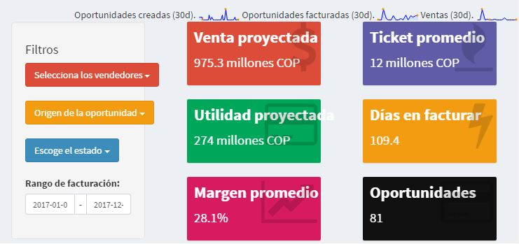

# Beneficios de la Implementación de un CRM

Nuestros sistemas de CRM no solo han permitido a nuestros clientes poder visualizar información relevante de forma ordenada, clara y concisa, sino que además les han ofrecido los siguientes beneficios:

- Medición en tiempo real del logro de objetivos.
- Formulación de estrategias de adquisición y retención de clientes, sustentada en información veraz y oportuna.